# Risk Factor Analysis

## Outcome Variable

**Outcome Variable:** ever_wasted

## Predictor Variables

**Intervention Variable:** exclfeed3

**Adjustment Set:**

- arm
- sex
- W_mage
- meducyrs
- feducyrs
- hhwealth_quart
- hfoodsec
- W_mhtcm
- vagbrth
- W_gagebrth
- W_birthwt
- W_birthlen
- W_nrooms
- W_nchldlt5
- month
- brthmon
- W_parity
- impfloor
- impsan
- safeh20
- delta_W_mage
- delta_meducyrs
- delta_feducyrs
- delta_hhwealth_quart
- delta_hfoodsec
- delta_W_mhtcm
- delta_vagbrth
- delta_W_gagebrth
- delta_W_birthwt
- delta_W_birthlen
- delta_W_nrooms
- delta_W_nchldlt5
- delta_month
- delta_brthmon
- delta_W_parity
- delta_impfloor
- delta_impsan
- delta_safeh20

## Stratifying Variables

The analysis was stratified on these variable(s):

- agecat
- studyid
- country

## Data Summary

| agecat | studyid | country | exclfeed3 | ever_wasted | n_cell | n |
| --- | --- | --- | --- | --- | --- | --- |
| 0-24 months (no birth wast) | ki0047075b-MAL-ED | BANGLADESH | 1 | 0 | 138 | 248 |
| 0-24 months (no birth wast) | ki0047075b-MAL-ED | BANGLADESH | 1 | 1 | 43 | 248 |
| 0-24 months (no birth wast) | ki0047075b-MAL-ED | BANGLADESH | 0 | 0 | 55 | 248 |
| 0-24 months (no birth wast) | ki0047075b-MAL-ED | BANGLADESH | 0 | 1 | 12 | 248 |
| 0-24 months (no birth wast) | ki0047075b-MAL-ED | BRAZIL | 1 | 0 | 80 | 224 |
| 0-24 months (no birth wast) | ki0047075b-MAL-ED | BRAZIL | 1 | 1 | 4 | 224 |
| 0-24 months (no birth wast) | ki0047075b-MAL-ED | BRAZIL | 0 | 0 | 132 | 224 |
| 0-24 months (no birth wast) | ki0047075b-MAL-ED | BRAZIL | 0 | 1 | 8 | 224 |
| 0-24 months (no birth wast) | ki0047075b-MAL-ED | INDIA | 1 | 0 | 93 | 235 |
| 0-24 months (no birth wast) | ki0047075b-MAL-ED | INDIA | 1 | 1 | 51 | 235 |
| 0-24 months (no birth wast) | ki0047075b-MAL-ED | INDIA | 0 | 0 | 54 | 235 |
| 0-24 months (no birth wast) | ki0047075b-MAL-ED | INDIA | 0 | 1 | 37 | 235 |
| 0-24 months (no birth wast) | ki0047075b-MAL-ED | NEPAL | 1 | 0 | 68 | 234 |
| 0-24 months (no birth wast) | ki0047075b-MAL-ED | NEPAL | 1 | 1 | 17 | 234 |
| 0-24 months (no birth wast) | ki0047075b-MAL-ED | NEPAL | 0 | 0 | 121 | 234 |
| 0-24 months (no birth wast) | ki0047075b-MAL-ED | NEPAL | 0 | 1 | 28 | 234 |
| 0-24 months (no birth wast) | ki0047075b-MAL-ED | PERU | 1 | 0 | 66 | 286 |
| 0-24 months (no birth wast) | ki0047075b-MAL-ED | PERU | 1 | 1 | 4 | 286 |
| 0-24 months (no birth wast) | ki0047075b-MAL-ED | PERU | 0 | 0 | 201 | 286 |
| 0-24 months (no birth wast) | ki0047075b-MAL-ED | PERU | 0 | 1 | 15 | 286 |
| 0-24 months (no birth wast) | ki0047075b-MAL-ED | SOUTH AFRICA | 1 | 0 | 31 | 275 |
| 0-24 months (no birth wast) | ki0047075b-MAL-ED | SOUTH AFRICA | 1 | 1 | 3 | 275 |
| 0-24 months (no birth wast) | ki0047075b-MAL-ED | SOUTH AFRICA | 0 | 0 | 200 | 275 |
| 0-24 months (no birth wast) | ki0047075b-MAL-ED | SOUTH AFRICA | 0 | 1 | 41 | 275 |
| 0-24 months (no birth wast) | ki0047075b-MAL-ED | TANZANIA, UNITED REPUBLIC OF | 1 | 0 | 61 | 249 |
| 0-24 months (no birth wast) | ki0047075b-MAL-ED | TANZANIA, UNITED REPUBLIC OF | 1 | 1 | 8 | 249 |
| 0-24 months (no birth wast) | ki0047075b-MAL-ED | TANZANIA, UNITED REPUBLIC OF | 0 | 0 | 158 | 249 |
| 0-24 months (no birth wast) | ki0047075b-MAL-ED | TANZANIA, UNITED REPUBLIC OF | 0 | 1 | 22 | 249 |
| 0-24 months (no birth wast) | ki1000108-CMC-V-BCS-2002 | INDIA | 1 | 0 | 4 | 10 |
| 0-24 months (no birth wast) | ki1000108-CMC-V-BCS-2002 | INDIA | 1 | 1 | 6 | 10 |

[output cut: 162 more lines]

The following strata were considered:

- agecat: 0-24 months (no birth wast), studyid: ki0047075b-MAL-ED, country: BANGLADESH
- agecat: 0-24 months (no birth wast), studyid: ki0047075b-MAL-ED, country: BRAZIL
- agecat: 0-24 months (no birth wast), studyid: ki0047075b-MAL-ED, country: INDIA
- agecat: 0-24 months (no birth wast), studyid: ki0047075b-MAL-ED, country: NEPAL
- agecat: 0-24 months (no birth wast), studyid: ki0047075b-MAL-ED, country: PERU
- agecat: 0-24 months (no birth wast), studyid: ki0047075b-MAL-ED, country: SOUTH AFRICA
- agecat: 0-24 months (no birth wast), studyid: ki0047075b-MAL-ED, country: TANZANIA, UNITED REPUBLIC OF
- agecat: 0-24 months (no birth wast), studyid: ki1000108-CMC-V-BCS-2002, country: INDIA
- agecat: 0-24 months (no birth wast), studyid: ki1000108-IRC, country: INDIA
- agecat: 0-24 months (no birth wast), studyid: ki1000109-EE, country: PAKISTAN
- agecat: 0-24 months (no birth wast), studyid: ki1000304b-SAS-CompFeed, country: INDIA
- agecat: 0-24 months (no birth wast), studyid: ki1017093b-PROVIDE, country: BANGLADESH
- agecat: 0-24 months (no birth wast), studyid: ki1101329-Keneba, country: GAMBIA
- agecat: 0-24 months (no birth wast), studyid: ki1113344-GMS-Nepal, country: NEPAL
- agecat: 0-24 months (no birth wast), studyid: kiGH5241-JiVitA-3, country: BANGLADESH
- agecat: 0-24 months (no birth wast), studyid: kiGH5241-JiVitA-4, country: BANGLADESH
- agecat: 0-6 months (no birth wast), studyid: ki0047075b-MAL-ED, country: BANGLADESH
- agecat: 0-6 months (no birth wast), studyid: ki0047075b-MAL-ED, country: BRAZIL
- agecat: 0-6 months (no birth wast), studyid: ki0047075b-MAL-ED, country: INDIA
- agecat: 0-6 months (no birth wast), studyid: ki0047075b-MAL-ED, country: NEPAL
- agecat: 0-6 months (no birth wast), studyid: ki0047075b-MAL-ED, country: PERU
- agecat: 0-6 months (no birth wast), studyid: ki0047075b-MAL-ED, country: SOUTH AFRICA
- agecat: 0-6 months (no birth wast), studyid: ki0047075b-MAL-ED, country: TANZANIA, UNITED REPUBLIC OF
- agecat: 0-6 months (no birth wast), studyid: ki1000108-CMC-V-BCS-2002, country: INDIA
- agecat: 0-6 months (no birth wast), studyid: ki1000108-IRC, country: INDIA
- agecat: 0-6 months (no birth wast), studyid: ki1000109-EE, country: PAKISTAN
- agecat: 0-6 months (no birth wast), studyid: ki1000304b-SAS-CompFeed, country: INDIA
- agecat: 0-6 months (no birth wast), studyid: ki1017093b-PROVIDE, country: BANGLADESH
- agecat: 0-6 months (no birth wast), studyid: ki1101329-Keneba, country: GAMBIA
- agecat: 0-6 months (no birth wast), studyid: ki1113344-GMS-Nepal, country: NEPAL
- agecat: 0-6 months (no birth wast), studyid: kiGH5241-JiVitA-3, country: BANGLADESH
- agecat: 0-6 months (no birth wast), studyid: kiGH5241-JiVitA-4, country: BANGLADESH
- agecat: 6-24 months, studyid: ki0047075b-MAL-ED, country: BANGLADESH
- agecat: 6-24 months, studyid: ki0047075b-MAL-ED, country: BRAZIL
- agecat: 6-24 months, studyid: ki0047075b-MAL-ED, country: INDIA
- agecat: 6-24 months, studyid: ki0047075b-MAL-ED, country: NEPAL
- agecat: 6-24 months, studyid: ki0047075b-MAL-ED, country: PERU
- agecat: 6-24 months, studyid: ki0047075b-MAL-ED, country: SOUTH AFRICA
- agecat: 6-24 months, studyid: ki0047075b-MAL-ED, country: TANZANIA, UNITED REPUBLIC OF
- agecat: 6-24 months, studyid: ki1000108-CMC-V-BCS-2002, country: INDIA
- agecat: 6-24 months, studyid: ki1000108-IRC, country: INDIA
- agecat: 6-24 months, studyid: ki1000109-EE, country: PAKISTAN
- agecat: 6-24 months, studyid: ki1000304b-SAS-CompFeed, country: INDIA
- agecat: 6-24 months, studyid: ki1017093b-PROVIDE, country: BANGLADESH
- agecat: 6-24 months, studyid: ki1101329-Keneba, country: GAMBIA
- agecat: 6-24 months, studyid: ki1113344-GMS-Nepal, country: NEPAL
- agecat: 6-24 months, studyid: kiGH5241-JiVitA-3, country: BANGLADESH
- agecat: 6-24 months, studyid: kiGH5241-JiVitA-4, country: BANGLADESH

### Dropped Strata

Some strata were dropped due to rare outcomes:

- agecat: 0-24 months (no birth wast), studyid: ki0047075b-MAL-ED, country: BRAZIL
- agecat: 0-24 months (no birth wast), studyid: ki0047075b-MAL-ED, country: PERU
- agecat: 0-24 months (no birth wast), studyid: ki0047075b-MAL-ED, country: SOUTH AFRICA
- agecat: 0-24 months (no birth wast), studyid: ki1000108-CMC-V-BCS-2002, country: INDIA
- agecat: 0-24 months (no birth wast), studyid: ki1000108-IRC, country: INDIA
- agecat: 0-24 months (no birth wast), studyid: kiGH5241-JiVitA-4, country: BANGLADESH
- agecat: 0-6 months (no birth wast), studyid: ki0047075b-MAL-ED, country: BRAZIL
- agecat: 0-6 months (no birth wast), studyid: ki0047075b-MAL-ED, country: PERU
- agecat: 0-6 months (no birth wast), studyid: ki0047075b-MAL-ED, country: SOUTH AFRICA
- agecat: 0-6 months (no birth wast), studyid: ki0047075b-MAL-ED, country: TANZANIA, UNITED REPUBLIC OF
- agecat: 0-6 months (no birth wast), studyid: ki1000108-CMC-V-BCS-2002, country: INDIA
- agecat: 0-6 months (no birth wast), studyid: ki1000108-IRC, country: INDIA
- agecat: 0-6 months (no birth wast), studyid: kiGH5241-JiVitA-4, country: BANGLADESH
- agecat: 6-24 months, studyid: ki0047075b-MAL-ED, country: BRAZIL
- agecat: 6-24 months, studyid: ki0047075b-MAL-ED, country: PERU
- agecat: 6-24 months, studyid: ki0047075b-MAL-ED, country: SOUTH AFRICA
- agecat: 6-24 months, studyid: ki1000108-CMC-V-BCS-2002, country: INDIA
- agecat: 6-24 months, studyid: ki1000108-IRC, country: INDIA
- agecat: 6-24 months, studyid: kiGH5241-JiVitA-4, country: BANGLADESH

## Methods Detail

We’re interested in the causal parameters $E[Y_a]$ for all values of $a \in \mathcal{A}$. These parameters represent the mean outcome if, possibly contrary to fact, we intervened to set all units to have $A=a$. Under the randomization and positivity assumptions, these are identified by the statistical parameters $\psi_a=E_W[E_{Y|A,W}(Y|A=a,W)]$. In addition, we’re interested in the mean of $Y$, $E[Y]$ under no intervention (the observed mean). We will estimate these parameters by using SuperLearner to fit the relevant likelihood factors – $E_{Y|A,W}(Y|A=a,W)$ and $p(A=a|W)$, and then updating our likelihood fit using a joint TMLE.

For unadjusted analyses ($W=\{\}$), initial likelihoods were estimated using Lrnr_glm to estimate the simple $E(Y|A)$ and Lrnr_mean to estimate $p(A)$. For adjusted analyses, a small library containing Lrnr_glmnet, Lrnr_xgboost, and Lrnr_mean was used.

Having estimated these parameters, we will then use the delta method to estimate relative risks and attributable risks relative to a prespecified baseline level of $A$.

# Results Detail

## Results Plots

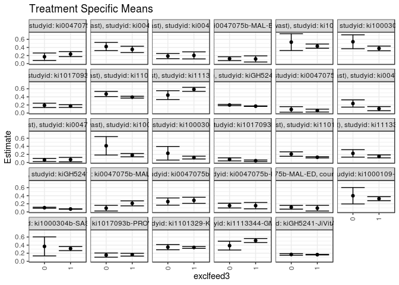

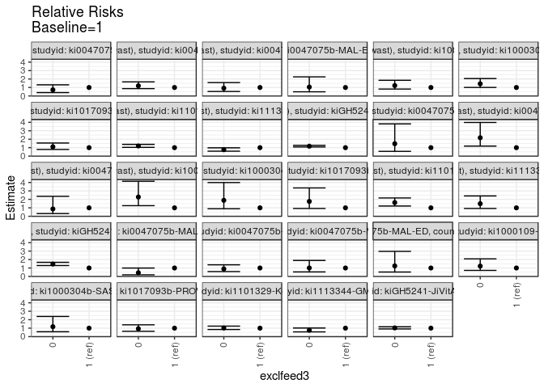

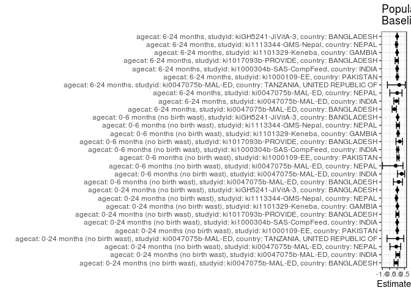

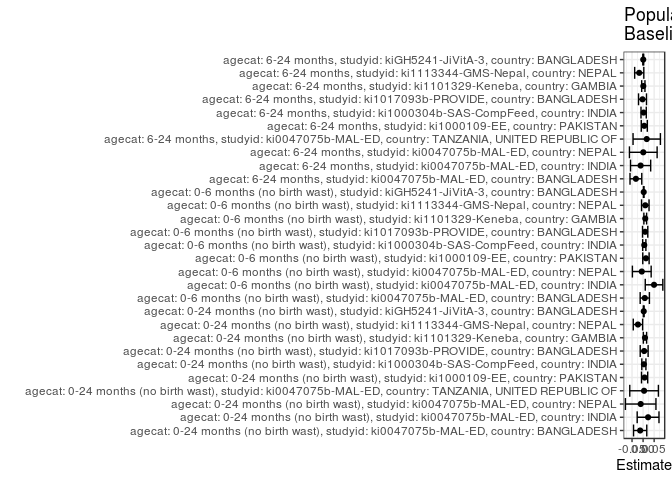

## Results Table

### Parameter: TSM

| agecat | studyid | country | intervention_level | baseline_level | estimate | ci_lower | ci_upper |
| --- | --- | --- | --- | --- | --- | --- | --- |
| 0-24 months (no birth wast) | ki0047075b-MAL-ED | BANGLADESH | 1 | NA | 0.2350298 | 0.1729399 | 0.2971197 |
| 0-24 months (no birth wast) | ki0047075b-MAL-ED | BANGLADESH | 0 | NA | 0.1703712 | 0.0785850 | 0.2621575 |
| 0-24 months (no birth wast) | ki0047075b-MAL-ED | INDIA | 1 | NA | 0.3518841 | 0.2740973 | 0.4296709 |
| 0-24 months (no birth wast) | ki0047075b-MAL-ED | INDIA | 0 | NA | 0.4225674 | 0.3208996 | 0.5242351 |
| 0-24 months (no birth wast) | ki0047075b-MAL-ED | NEPAL | 1 | NA | 0.2032106 | 0.1160756 | 0.2903455 |
| 0-24 months (no birth wast) | ki0047075b-MAL-ED | NEPAL | 0 | NA | 0.1863328 | 0.1234960 | 0.2491696 |
| 0-24 months (no birth wast) | ki0047075b-MAL-ED | TANZANIA, UNITED REPUBLIC OF | 1 | NA | 0.1159420 | 0.0402486 | 0.1916355 |
| 0-24 months (no birth wast) | ki0047075b-MAL-ED | TANZANIA, UNITED REPUBLIC OF | 0 | NA | 0.1222222 | 0.0742761 | 0.1701683 |
| 0-24 months (no birth wast) | ki1000109-EE | PAKISTAN | 1 | NA | 0.4319902 | 0.3799882 | 0.4839923 |
| 0-24 months (no birth wast) | ki1000109-EE | PAKISTAN | 0 | NA | 0.5309964 | 0.3226587 | 0.7393342 |
| 0-24 months (no birth wast) | ki1000304b-SAS-CompFeed | INDIA | 1 | NA | 0.3757309 | 0.3177201 | 0.4337417 |
| 0-24 months (no birth wast) | ki1000304b-SAS-CompFeed | INDIA | 0 | NA | 0.5403211 | 0.3689051 | 0.7117371 |
| 0-24 months (no birth wast) | ki1017093b-PROVIDE | BANGLADESH | 1 | NA | 0.1727236 | 0.1392214 | 0.2062259 |
| 0-24 months (no birth wast) | ki1017093b-PROVIDE | BANGLADESH | 0 | NA | 0.1905065 | 0.1369094 | 0.2441036 |
| 0-24 months (no birth wast) | ki1101329-Keneba | GAMBIA | 1 | NA | 0.3922250 | 0.3696910 | 0.4147591 |
| 0-24 months (no birth wast) | ki1101329-Keneba | GAMBIA | 0 | NA | 0.4709717 | 0.4071037 | 0.5348396 |
| 0-24 months (no birth wast) | ki1113344-GMS-Nepal | NEPAL | 1 | NA | 0.5855017 | 0.5361086 | 0.6348947 |
| 0-24 months (no birth wast) | ki1113344-GMS-Nepal | NEPAL | 0 | NA | 0.4430965 | 0.3339396 | 0.5522534 |
| 0-24 months (no birth wast) | kiGH5241-JiVitA-3 | BANGLADESH | 1 | NA | 0.1695844 | 0.1639404 | 0.1752284 |
| 0-24 months (no birth wast) | kiGH5241-JiVitA-3 | BANGLADESH | 0 | NA | 0.1989474 | 0.1830436 | 0.2148511 |
| 0-6 months (no birth wast) | ki0047075b-MAL-ED | BANGLADESH | 1 | NA | 0.0611111 | 0.0260472 | 0.0961750 |
| 0-6 months (no birth wast) | ki0047075b-MAL-ED | BANGLADESH | 0 | NA | 0.0895522 | 0.0210417 | 0.1580628 |
| 0-6 months (no birth wast) | ki0047075b-MAL-ED | INDIA | 1 | NA | 0.1085632 | 0.0577915 | 0.1593350 |
| 0-6 months (no birth wast) | ki0047075b-MAL-ED | INDIA | 0 | NA | 0.2358184 | 0.1459048 | 0.3257319 |
| 0-6 months (no birth wast) | ki0047075b-MAL-ED | NEPAL | 1 | NA | 0.0705882 | 0.0160191 | 0.1251573 |
| 0-6 months (no birth wast) | ki0047075b-MAL-ED | NEPAL | 0 | NA | 0.0612245 | 0.0223852 | 0.1000637 |
| 0-6 months (no birth wast) | ki1000109-EE | PAKISTAN | 1 | NA | 0.1806273 | 0.1398925 | 0.2213620 |
| 0-6 months (no birth wast) | ki1000109-EE | PAKISTAN | 0 | NA | 0.4116698 | 0.1835973 | 0.6397423 |
| 0-6 months (no birth wast) | ki1000304b-SAS-CompFeed | INDIA | 1 | NA | 0.1204819 | 0.0857775 | 0.1551864 |
| 0-6 months (no birth wast) | ki1000304b-SAS-CompFeed | INDIA | 0 | NA | 0.2272727 | 0.0595457 | 0.3949997 |
| 0-6 months (no birth wast) | ki1017093b-PROVIDE | BANGLADESH | 1 | NA | 0.0433850 | 0.0253484 | 0.0614216 |
| 0-6 months (no birth wast) | ki1017093b-PROVIDE | BANGLADESH | 0 | NA | 0.0763697 | 0.0387332 | 0.1140062 |
| 0-6 months (no birth wast) | ki1101329-Keneba | GAMBIA | 1 | NA | 0.1282124 | 0.1127456 | 0.1436791 |
| 0-6 months (no birth wast) | ki1101329-Keneba | GAMBIA | 0 | NA | 0.2079064 | 0.1530448 | 0.2627680 |
| 0-6 months (no birth wast) | ki1113344-GMS-Nepal | NEPAL | 1 | NA | 0.1507029 | 0.1143214 | 0.1870844 |
| 0-6 months (no birth wast) | ki1113344-GMS-Nepal | NEPAL | 0 | NA | 0.2244936 | 0.1320314 | 0.3169557 |
| 0-6 months (no birth wast) | kiGH5241-JiVitA-3 | BANGLADESH | 1 | NA | 0.0704355 | 0.0665441 | 0.0743269 |
| 0-6 months (no birth wast) | kiGH5241-JiVitA-3 | BANGLADESH | 0 | NA | 0.1034458 | 0.0909127 | 0.1159789 |
| 6-24 months | ki0047075b-MAL-ED | BANGLADESH | 1 | NA | 0.2105263 | 0.1492921 | 0.2717605 |
| 6-24 months | ki0047075b-MAL-ED | BANGLADESH | 0 | NA | 0.0923077 | 0.0217894 | 0.1628260 |
| 6-24 months | ki0047075b-MAL-ED | INDIA | 1 | NA | 0.2859567 | 0.2107731 | 0.3611403 |
| 6-24 months | ki0047075b-MAL-ED | INDIA | 0 | NA | 0.2546236 | 0.1654722 | 0.3437751 |
| 6-24 months | ki0047075b-MAL-ED | NEPAL | 1 | NA | 0.1542678 | 0.0761991 | 0.2323366 |
| 6-24 months | ki0047075b-MAL-ED | NEPAL | 0 | NA | 0.1551695 | 0.0962678 | 0.2140712 |
| 6-24 months | ki0047075b-MAL-ED | TANZANIA, UNITED REPUBLIC OF | 1 | NA | 0.0923077 | 0.0217913 | 0.1628241 |
| 6-24 months | ki0047075b-MAL-ED | TANZANIA, UNITED REPUBLIC OF | 0 | NA | 0.1149425 | 0.0674517 | 0.1624334 |
| 6-24 months | ki1000109-EE | PAKISTAN | 1 | NA | 0.3261559 | 0.2767492 | 0.3755626 |
| 6-24 months | ki1000109-EE | PAKISTAN | 0 | NA | 0.3987969 | 0.1958775 | 0.6017163 |
| 6-24 months | ki1000304b-SAS-CompFeed | INDIA | 1 | NA | 0.3140704 | 0.2638452 | 0.3642955 |
| 6-24 months | ki1000304b-SAS-CompFeed | INDIA | 0 | NA | 0.3684211 | 0.1333387 | 0.6035034 |
| 6-24 months | ki1017093b-PROVIDE | BANGLADESH | 1 | NA | 0.1635619 | 0.1286355 | 0.1984883 |
| 6-24 months | ki1017093b-PROVIDE | BANGLADESH | 0 | NA | 0.1533241 | 0.1013107 | 0.2053376 |
| 6-24 months | ki1101329-Keneba | GAMBIA | 1 | NA | 0.3424165 | 0.3198949 | 0.3649380 |
| 6-24 months | ki1101329-Keneba | GAMBIA | 0 | NA | 0.3497581 | 0.2855647 | 0.4139515 |
| 6-24 months | ki1113344-GMS-Nepal | NEPAL | 1 | NA | 0.5131029 | 0.4631929 | 0.5630129 |
| 6-24 months | ki1113344-GMS-Nepal | NEPAL | 0 | NA | 0.3873029 | 0.2782861 | 0.4963196 |
| 6-24 months | kiGH5241-JiVitA-3 | BANGLADESH | 1 | NA | 0.1641431 | 0.1576637 | 0.1706225 |
| 6-24 months | kiGH5241-JiVitA-3 | BANGLADESH | 0 | NA | 0.1686267 | 0.1484449 | 0.1888086 |

### Parameter: E(Y)

| agecat | studyid | country | intervention_level | baseline_level | estimate | ci_lower | ci_upper |
| --- | --- | --- | --- | --- | --- | --- | --- |
| 0-24 months (no birth wast) | ki0047075b-MAL-ED | BANGLADESH | NA | NA | 0.2217742 | 0.1699649 | 0.2735835 |
| 0-24 months (no birth wast) | ki0047075b-MAL-ED | INDIA | NA | NA | 0.3744681 | 0.3124566 | 0.4364796 |
| 0-24 months (no birth wast) | ki0047075b-MAL-ED | NEPAL | NA | NA | 0.1923077 | 0.1417029 | 0.2429125 |
| 0-24 months (no birth wast) | ki0047075b-MAL-ED | TANZANIA, UNITED REPUBLIC OF | NA | NA | 0.1204819 | 0.0799679 | 0.1609960 |
| 0-24 months (no birth wast) | ki1000109-EE | PAKISTAN | NA | NA | 0.4388298 | 0.3886039 | 0.4890557 |
| 0-24 months (no birth wast) | ki1000304b-SAS-CompFeed | INDIA | NA | NA | 0.3792325 | 0.3255512 | 0.4329138 |
| 0-24 months (no birth wast) | ki1017093b-PROVIDE | BANGLADESH | NA | NA | 0.1775837 | 0.1489858 | 0.2061816 |
| 0-24 months (no birth wast) | ki1101329-Keneba | GAMBIA | NA | NA | 0.4007937 | 0.3793963 | 0.4221910 |
| 0-24 months (no birth wast) | ki1113344-GMS-Nepal | NEPAL | NA | NA | 0.5622318 | 0.5171396 | 0.6073240 |
| 0-24 months (no birth wast) | kiGH5241-JiVitA-3 | BANGLADESH | NA | NA | 0.1725236 | 0.1670497 | 0.1779975 |
| 0-6 months (no birth wast) | ki0047075b-MAL-ED | BANGLADESH | NA | NA | 0.0688259 | 0.0371906 | 0.1004612 |
| 0-6 months (no birth wast) | ki0047075b-MAL-ED | INDIA | NA | NA | 0.1581197 | 0.1112720 | 0.2049674 |
| 0-6 months (no birth wast) | ki0047075b-MAL-ED | NEPAL | NA | NA | 0.0646552 | 0.0329427 | 0.0963676 |
| 0-6 months (no birth wast) | ki1000109-EE | PAKISTAN | NA | NA | 0.1935484 | 0.1533466 | 0.2337501 |
| 0-6 months (no birth wast) | ki1000304b-SAS-CompFeed | INDIA | NA | NA | 0.1258581 | 0.0910745 | 0.1606418 |
| 0-6 months (no birth wast) | ki1017093b-PROVIDE | BANGLADESH | NA | NA | 0.0527086 | 0.0359384 | 0.0694789 |
| 0-6 months (no birth wast) | ki1101329-Keneba | GAMBIA | NA | NA | 0.1380169 | 0.1229232 | 0.1531107 |
| 0-6 months (no birth wast) | ki1113344-GMS-Nepal | NEPAL | NA | NA | 0.1607143 | 0.1266675 | 0.1947611 |
| 0-6 months (no birth wast) | kiGH5241-JiVitA-3 | BANGLADESH | NA | NA | 0.0732993 | 0.0695038 | 0.0770947 |
| 6-24 months | ki0047075b-MAL-ED | BANGLADESH | NA | NA | 0.1779661 | 0.1290640 | 0.2268682 |
| 6-24 months | ki0047075b-MAL-ED | INDIA | NA | NA | 0.2746781 | 0.2172425 | 0.3321138 |
| 6-24 months | ki0047075b-MAL-ED | NEPAL | NA | NA | 0.1551724 | 0.1084814 | 0.2018634 |
| 6-24 months | ki0047075b-MAL-ED | TANZANIA, UNITED REPUBLIC OF | NA | NA | 0.1087866 | 0.0692283 | 0.1483450 |
| 6-24 months | ki1000109-EE | PAKISTAN | NA | NA | 0.3315508 | 0.2837756 | 0.3793260 |
| 6-24 months | ki1000304b-SAS-CompFeed | INDIA | NA | NA | 0.3165468 | 0.2711185 | 0.3619751 |
| 6-24 months | ki1017093b-PROVIDE | BANGLADESH | NA | NA | 0.1609756 | 0.1319065 | 0.1900447 |
| 6-24 months | ki1101329-Keneba | GAMBIA | NA | NA | 0.3434555 | 0.3221539 | 0.3647571 |
| 6-24 months | ki1113344-GMS-Nepal | NEPAL | NA | NA | 0.4957265 | 0.4503800 | 0.5410730 |
| 6-24 months | kiGH5241-JiVitA-3 | BANGLADESH | NA | NA | 0.1648726 | 0.1585930 | 0.1711523 |

### Parameter: RR

| agecat | studyid | country | intervention_level | baseline_level | estimate | ci_lower | ci_upper |
| --- | --- | --- | --- | --- | --- | --- | --- |
| 0-24 months (no birth wast) | ki0047075b-MAL-ED | BANGLADESH | 1 | 1 | 1.0000000 | 1.0000000 | 1.0000000 |
| 0-24 months (no birth wast) | ki0047075b-MAL-ED | BANGLADESH | 0 | 1 | 0.7248920 | 0.3992859 | 1.3160201 |
| 0-24 months (no birth wast) | ki0047075b-MAL-ED | INDIA | 1 | 1 | 1.0000000 | 1.0000000 | 1.0000000 |
| 0-24 months (no birth wast) | ki0047075b-MAL-ED | INDIA | 0 | 1 | 1.2008710 | 0.8665872 | 1.6641040 |
| 0-24 months (no birth wast) | ki0047075b-MAL-ED | NEPAL | 1 | 1 | 1.0000000 | 1.0000000 | 1.0000000 |
| 0-24 months (no birth wast) | ki0047075b-MAL-ED | NEPAL | 0 | 1 | 0.9169445 | 0.5315732 | 1.5816959 |
| 0-24 months (no birth wast) | ki0047075b-MAL-ED | TANZANIA, UNITED REPUBLIC OF | 1 | 1 | 1.0000000 | 1.0000000 | 1.0000000 |
| 0-24 months (no birth wast) | ki0047075b-MAL-ED | TANZANIA, UNITED REPUBLIC OF | 0 | 1 | 1.0541667 | 0.4921861 | 2.2578195 |
| 0-24 months (no birth wast) | ki1000109-EE | PAKISTAN | 1 | 1 | 1.0000000 | 1.0000000 | 1.0000000 |
| 0-24 months (no birth wast) | ki1000109-EE | PAKISTAN | 0 | 1 | 1.2291862 | 0.8157803 | 1.8520903 |
| 0-24 months (no birth wast) | ki1000304b-SAS-CompFeed | INDIA | 1 | 1 | 1.0000000 | 1.0000000 | 1.0000000 |
| 0-24 months (no birth wast) | ki1000304b-SAS-CompFeed | INDIA | 0 | 1 | 1.4380533 | 1.0053936 | 2.0569033 |
| 0-24 months (no birth wast) | ki1017093b-PROVIDE | BANGLADESH | 1 | 1 | 1.0000000 | 1.0000000 | 1.0000000 |
| 0-24 months (no birth wast) | ki1017093b-PROVIDE | BANGLADESH | 0 | 1 | 1.1029555 | 0.7855615 | 1.5485875 |
| 0-24 months (no birth wast) | ki1101329-Keneba | GAMBIA | 1 | 1 | 1.0000000 | 1.0000000 | 1.0000000 |
| 0-24 months (no birth wast) | ki1101329-Keneba | GAMBIA | 0 | 1 | 1.2007689 | 1.0375050 | 1.3897245 |
| 0-24 months (no birth wast) | ki1113344-GMS-Nepal | NEPAL | 1 | 1 | 1.0000000 | 1.0000000 | 1.0000000 |
| 0-24 months (no birth wast) | ki1113344-GMS-Nepal | NEPAL | 0 | 1 | 0.7567810 | 0.5834635 | 0.9815824 |
| 0-24 months (no birth wast) | kiGH5241-JiVitA-3 | BANGLADESH | 1 | 1 | 1.0000000 | 1.0000000 | 1.0000000 |
| 0-24 months (no birth wast) | kiGH5241-JiVitA-3 | BANGLADESH | 0 | 1 | 1.1731467 | 1.0792706 | 1.2751882 |
| 0-6 months (no birth wast) | ki0047075b-MAL-ED | BANGLADESH | 1 | 1 | 1.0000000 | 1.0000000 | 1.0000000 |
| 0-6 months (no birth wast) | ki0047075b-MAL-ED | BANGLADESH | 0 | 1 | 1.4654003 | 0.5631763 | 3.8130119 |
| 0-6 months (no birth wast) | ki0047075b-MAL-ED | INDIA | 1 | 1 | 1.0000000 | 1.0000000 | 1.0000000 |
| 0-6 months (no birth wast) | ki0047075b-MAL-ED | INDIA | 0 | 1 | 2.1721757 | 1.1857952 | 3.9790575 |
| 0-6 months (no birth wast) | ki0047075b-MAL-ED | NEPAL | 1 | 1 | 1.0000000 | 1.0000000 | 1.0000000 |
| 0-6 months (no birth wast) | ki0047075b-MAL-ED | NEPAL | 0 | 1 | 0.8673469 | 0.3190701 | 2.3577600 |
| 0-6 months (no birth wast) | ki1000109-EE | PAKISTAN | 1 | 1 | 1.0000000 | 1.0000000 | 1.0000000 |
| 0-6 months (no birth wast) | ki1000109-EE | PAKISTAN | 0 | 1 | 2.2791120 | 1.2537642 | 4.1430051 |
| 0-6 months (no birth wast) | ki1000304b-SAS-CompFeed | INDIA | 1 | 1 | 1.0000000 | 1.0000000 | 1.0000000 |
| 0-6 months (no birth wast) | ki1000304b-SAS-CompFeed | INDIA | 0 | 1 | 1.8863636 | 0.8915751 | 3.9911028 |
| 0-6 months (no birth wast) | ki1017093b-PROVIDE | BANGLADESH | 1 | 1 | 1.0000000 | 1.0000000 | 1.0000000 |
| 0-6 months (no birth wast) | ki1017093b-PROVIDE | BANGLADESH | 0 | 1 | 1.7602790 | 0.9244025 | 3.3519839 |
| 0-6 months (no birth wast) | ki1101329-Keneba | GAMBIA | 1 | 1 | 1.0000000 | 1.0000000 | 1.0000000 |
| 0-6 months (no birth wast) | ki1101329-Keneba | GAMBIA | 0 | 1 | 1.6215781 | 1.2143540 | 2.1653615 |
| 0-6 months (no birth wast) | ki1113344-GMS-Nepal | NEPAL | 1 | 1 | 1.0000000 | 1.0000000 | 1.0000000 |
| 0-6 months (no birth wast) | ki1113344-GMS-Nepal | NEPAL | 0 | 1 | 1.4896431 | 0.9225539 | 2.4053193 |
| 0-6 months (no birth wast) | kiGH5241-JiVitA-3 | BANGLADESH | 1 | 1 | 1.0000000 | 1.0000000 | 1.0000000 |
| 0-6 months (no birth wast) | kiGH5241-JiVitA-3 | BANGLADESH | 0 | 1 | 1.4686598 | 1.2913198 | 1.6703544 |
| 6-24 months | ki0047075b-MAL-ED | BANGLADESH | 1 | 1 | 1.0000000 | 1.0000000 | 1.0000000 |
| 6-24 months | ki0047075b-MAL-ED | BANGLADESH | 0 | 1 | 0.4384616 | 0.1936062 | 0.9929874 |
| 6-24 months | ki0047075b-MAL-ED | INDIA | 1 | 1 | 1.0000000 | 1.0000000 | 1.0000000 |
| 6-24 months | ki0047075b-MAL-ED | INDIA | 0 | 1 | 0.8904271 | 0.5762814 | 1.3758217 |
| 6-24 months | ki0047075b-MAL-ED | NEPAL | 1 | 1 | 1.0000000 | 1.0000000 | 1.0000000 |
| 6-24 months | ki0047075b-MAL-ED | NEPAL | 0 | 1 | 1.0058447 | 0.5343692 | 1.8933046 |
| 6-24 months | ki0047075b-MAL-ED | TANZANIA, UNITED REPUBLIC OF | 1 | 1 | 1.0000000 | 1.0000000 | 1.0000000 |
| 6-24 months | ki0047075b-MAL-ED | TANZANIA, UNITED REPUBLIC OF | 0 | 1 | 1.2452106 | 0.5224651 | 2.9677571 |
| 6-24 months | ki1000109-EE | PAKISTAN | 1 | 1 | 1.0000000 | 1.0000000 | 1.0000000 |
| 6-24 months | ki1000109-EE | PAKISTAN | 0 | 1 | 1.2227186 | 0.7186873 | 2.0802384 |
| 6-24 months | ki1000304b-SAS-CompFeed | INDIA | 1 | 1 | 1.0000000 | 1.0000000 | 1.0000000 |
| 6-24 months | ki1000304b-SAS-CompFeed | INDIA | 0 | 1 | 1.1730526 | 0.5767231 | 2.3859846 |
| 6-24 months | ki1017093b-PROVIDE | BANGLADESH | 1 | 1 | 1.0000000 | 1.0000000 | 1.0000000 |
| 6-24 months | ki1017093b-PROVIDE | BANGLADESH | 0 | 1 | 0.9374074 | 0.6297345 | 1.3954018 |
| 6-24 months | ki1101329-Keneba | GAMBIA | 1 | 1 | 1.0000000 | 1.0000000 | 1.0000000 |
| 6-24 months | ki1101329-Keneba | GAMBIA | 0 | 1 | 1.0214406 | 0.8410872 | 1.2404669 |
| 6-24 months | ki1113344-GMS-Nepal | NEPAL | 1 | 1 | 1.0000000 | 1.0000000 | 1.0000000 |
| 6-24 months | ki1113344-GMS-Nepal | NEPAL | 0 | 1 | 0.7548250 | 0.5606066 | 1.0163289 |
| 6-24 months | kiGH5241-JiVitA-3 | BANGLADESH | 1 | 1 | 1.0000000 | 1.0000000 | 1.0000000 |
| 6-24 months | kiGH5241-JiVitA-3 | BANGLADESH | 0 | 1 | 1.0273154 | 0.9078037 | 1.1625608 |

### Parameter: PAR

| agecat | studyid | country | intervention_level | baseline_level | estimate | ci_lower | ci_upper |
| --- | --- | --- | --- | --- | --- | --- | --- |
| 0-24 months (no birth wast) | ki0047075b-MAL-ED | BANGLADESH | 1 | NA | -0.0132556 | -0.0431675 | 0.0166563 |
| 0-24 months (no birth wast) | ki0047075b-MAL-ED | INDIA | 1 | NA | 0.0225840 | -0.0267177 | 0.0718858 |
| 0-24 months (no birth wast) | ki0047075b-MAL-ED | NEPAL | 1 | NA | -0.0109029 | -0.0799688 | 0.0581631 |
| 0-24 months (no birth wast) | ki0047075b-MAL-ED | TANZANIA, UNITED REPUBLIC OF | 1 | NA | 0.0045399 | -0.0602328 | 0.0693126 |
| 0-24 months (no birth wast) | ki1000109-EE | PAKISTAN | 1 | NA | 0.0068395 | -0.0070984 | 0.0207775 |
| 0-24 months (no birth wast) | ki1000304b-SAS-CompFeed | INDIA | 1 | NA | 0.0035016 | -0.0057722 | 0.0127754 |
| 0-24 months (no birth wast) | ki1017093b-PROVIDE | BANGLADESH | 1 | NA | 0.0048601 | -0.0129626 | 0.0226827 |
| 0-24 months (no birth wast) | ki1101329-Keneba | GAMBIA | 1 | NA | 0.0085686 | 0.0011954 | 0.0159418 |
| 0-24 months (no birth wast) | ki1113344-GMS-Nepal | NEPAL | 1 | NA | -0.0232699 | -0.0444689 | -0.0020710 |
| 0-24 months (no birth wast) | kiGH5241-JiVitA-3 | BANGLADESH | 1 | NA | 0.0029392 | 0.0012108 | 0.0046676 |
| 0-6 months (no birth wast) | ki0047075b-MAL-ED | BANGLADESH | 1 | NA | 0.0077148 | -0.0132213 | 0.0286509 |
| 0-6 months (no birth wast) | ki0047075b-MAL-ED | INDIA | 1 | NA | 0.0495564 | 0.0098408 | 0.0892720 |
| 0-6 months (no birth wast) | ki0047075b-MAL-ED | NEPAL | 1 | NA | -0.0059331 | -0.0483768 | 0.0365106 |
| 0-6 months (no birth wast) | ki1000109-EE | PAKISTAN | 1 | NA | 0.0129211 | -0.0014708 | 0.0273130 |
| 0-6 months (no birth wast) | ki1000304b-SAS-CompFeed | INDIA | 1 | NA | 0.0053762 | -0.0018898 | 0.0126422 |
| 0-6 months (no birth wast) | ki1017093b-PROVIDE | BANGLADESH | 1 | NA | 0.0093236 | -0.0025689 | 0.0212161 |
| 0-6 months (no birth wast) | ki1101329-Keneba | GAMBIA | 1 | NA | 0.0098046 | 0.0035891 | 0.0160201 |
| 0-6 months (no birth wast) | ki1113344-GMS-Nepal | NEPAL | 1 | NA | 0.0100114 | -0.0069162 | 0.0269389 |
| 0-6 months (no birth wast) | kiGH5241-JiVitA-3 | BANGLADESH | 1 | NA | 0.0028638 | 0.0015583 | 0.0041692 |
| 6-24 months | ki0047075b-MAL-ED | BANGLADESH | 1 | NA | -0.0325602 | -0.0591546 | -0.0059658 |
| 6-24 months | ki0047075b-MAL-ED | INDIA | 1 | NA | -0.0112786 | -0.0568701 | 0.0343129 |
| 6-24 months | ki0047075b-MAL-ED | NEPAL | 1 | NA | 0.0009046 | -0.0616689 | 0.0634780 |
| 6-24 months | ki0047075b-MAL-ED | TANZANIA, UNITED REPUBLIC OF | 1 | NA | 0.0164789 | -0.0454298 | 0.0783876 |
| 6-24 months | ki1000109-EE | PAKISTAN | 1 | NA | 0.0053949 | -0.0082447 | 0.0190346 |
| 6-24 months | ki1000304b-SAS-CompFeed | INDIA | 1 | NA | 0.0024764 | -0.0094430 | 0.0143959 |
| 6-24 months | ki1017093b-PROVIDE | BANGLADESH | 1 | NA | -0.0025863 | -0.0205806 | 0.0154081 |
| 6-24 months | ki1101329-Keneba | GAMBIA | 1 | NA | 0.0010390 | -0.0063448 | 0.0084229 |
| 6-24 months | ki1113344-GMS-Nepal | NEPAL | 1 | NA | -0.0173764 | -0.0380576 | 0.0033048 |
| 6-24 months | kiGH5241-JiVitA-3 | BANGLADESH | 1 | NA | 0.0007295 | -0.0012504 | 0.0027094 |

### Parameter: PAF

| agecat | studyid | country | intervention_level | baseline_level | estimate | ci_lower | ci_upper |
| --- | --- | --- | --- | --- | --- | --- | --- |
| 0-24 months (no birth wast) | ki0047075b-MAL-ED | BANGLADESH | 1 | NA | -0.0597708 | -0.2030116 | 0.0664146 |
| 0-24 months (no birth wast) | ki0047075b-MAL-ED | INDIA | 1 | NA | 0.0603096 | -0.0810304 | 0.1831700 |
| 0-24 months (no birth wast) | ki0047075b-MAL-ED | NEPAL | 1 | NA | -0.0566949 | -0.4840648 | 0.2476042 |
| 0-24 months (no birth wast) | ki0047075b-MAL-ED | TANZANIA, UNITED REPUBLIC OF | 1 | NA | 0.0376812 | -0.6822643 | 0.4495172 |
| 0-24 months (no birth wast) | ki1000109-EE | PAKISTAN | 1 | NA | 0.0155859 | -0.0167286 | 0.0468733 |
| 0-24 months (no birth wast) | ki1000304b-SAS-CompFeed | INDIA | 1 | NA | 0.0092334 | -0.0160894 | 0.0339252 |
| 0-24 months (no birth wast) | ki1017093b-PROVIDE | BANGLADESH | 1 | NA | 0.0273677 | -0.0783996 | 0.1227616 |
| 0-24 months (no birth wast) | ki1101329-Keneba | GAMBIA | 1 | NA | 0.0213791 | 0.0027889 | 0.0396227 |
| 0-24 months (no birth wast) | ki1113344-GMS-Nepal | NEPAL | 1 | NA | -0.0413885 | -0.0800127 | -0.0041456 |
| 0-24 months (no birth wast) | kiGH5241-JiVitA-3 | BANGLADESH | 1 | NA | 0.0170366 | 0.0069839 | 0.0269875 |
| 0-6 months (no birth wast) | ki0047075b-MAL-ED | BANGLADESH | 1 | NA | 0.1120915 | -0.2453391 | 0.3669343 |
| 0-6 months (no birth wast) | ki0047075b-MAL-ED | INDIA | 1 | NA | 0.3134110 | 0.0286648 | 0.5146840 |
| 0-6 months (no birth wast) | ki0047075b-MAL-ED | NEPAL | 1 | NA | -0.0917647 | -0.9894929 | 0.4008774 |
| 0-6 months (no birth wast) | ki1000109-EE | PAKISTAN | 1 | NA | 0.0667591 | -0.0099105 | 0.1376082 |
| 0-6 months (no birth wast) | ki1000304b-SAS-CompFeed | INDIA | 1 | NA | 0.0427163 | -0.0166271 | 0.0985957 |
| 0-6 months (no birth wast) | ki1017093b-PROVIDE | BANGLADESH | 1 | NA | 0.1768900 | -0.0737577 | 0.3690289 |
| 0-6 months (no birth wast) | ki1101329-Keneba | GAMBIA | 1 | NA | 0.0710389 | 0.0253776 | 0.1145610 |
| 0-6 months (no birth wast) | ki1113344-GMS-Nepal | NEPAL | 1 | NA | 0.0622930 | -0.0485362 | 0.1614077 |
| 0-6 months (no birth wast) | kiGH5241-JiVitA-3 | BANGLADESH | 1 | NA | 0.0390694 | 0.0211776 | 0.0566341 |
| 6-24 months | ki0047075b-MAL-ED | BANGLADESH | 1 | NA | -0.1829574 | -0.3375029 | -0.0462693 |
| 6-24 months | ki0047075b-MAL-ED | INDIA | 1 | NA | -0.0410612 | -0.2207379 | 0.1121695 |
| 6-24 months | ki0047075b-MAL-ED | NEPAL | 1 | NA | 0.0058294 | -0.4914856 | 0.3373217 |
| 6-24 months | ki0047075b-MAL-ED | TANZANIA, UNITED REPUBLIC OF | 1 | NA | 0.1514792 | -0.6551987 | 0.5650145 |
| 6-24 months | ki1000109-EE | PAKISTAN | 1 | NA | 0.0162718 | -0.0257576 | 0.0565791 |
| 6-24 months | ki1000304b-SAS-CompFeed | INDIA | 1 | NA | 0.0078232 | -0.0309120 | 0.0451030 |
| 6-24 months | ki1017093b-PROVIDE | BANGLADESH | 1 | NA | -0.0160663 | -0.1341142 | 0.0896941 |
| 6-24 months | ki1101329-Keneba | GAMBIA | 1 | NA | 0.0030253 | -0.0187071 | 0.0242940 |
| 6-24 months | ki1113344-GMS-Nepal | NEPAL | 1 | NA | -0.0350524 | -0.0777392 | 0.0059437 |
| 6-24 months | kiGH5241-JiVitA-3 | BANGLADESH | 1 | NA | 0.0044247 | -0.0076483 | 0.0163531 |